# Part II -PISA2012 Data Slide Deck

## by Emmie Alaka

- Investigation Overview
- Dataset Overview
- Visualizations

## Investigation Overview

For the presentation, I focus on just the influence of Wealth,ICT Resources on Read Plausible Value Mean and Math Plausible Value Mean of the PISA2012 data and leave out most of the intermediate derivations.

I start by introducing the Math Plausible Value Mean and Read Plausible Value Mean, followed by ICT Resources Variable and Wealth.

Then later, I have plotted a colored Scatterplot of Math Plausible Value Mean, Read Plausible Value Mean and Wealth and ICT Resources. I've made sure to use different color palettes for each quality variable to make sure it is clear that they're different between plots.

## Dataset Overview

The Pisa Dataset has **485490** students and **636** features that describes each of them.

### Features in the dataset that support my investigation.

This **PISA2012** dataset has 636 columns, but we will only look at a few varibles that will help us answer our questions;

1. ICT resources.
2. Wealth
3. Immigration Status
4. Math Plausible Value Mean
5. Read Plausible Value Mean
6. Science Plausible Value Mean

## Visualizations

### Visualization 1:Histogram of Math Plausible Value Mean

First, I have created a function so as to minimize code repetition. This histogram depicts that the graph is unimodal with the largest number of students lyng between **400 and 600

```
"'This function outputs a histogram'"
```

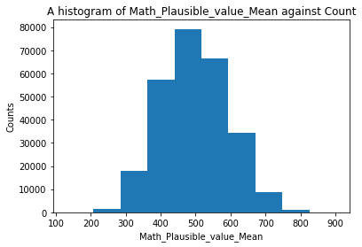

### Visualization 2: Histogram of Read Plausible Value Mean

This graph is also unimodal, with the highest number of students ranging between *400 and 600*

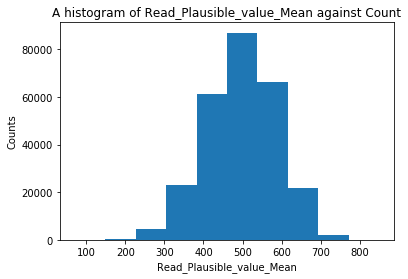

### Visualization 3: Histogram of Wealth

This graph is also unimodal with highest number of students lying just before zoro and after one. This shows that most of the students are not wealthy.

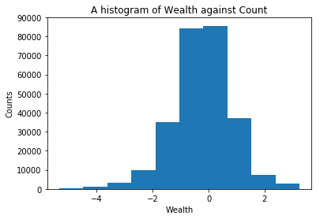

### Visualization 4: Histogram of ICT Resources

The graph is almost left skewed with most students havig access to ICT Resources.

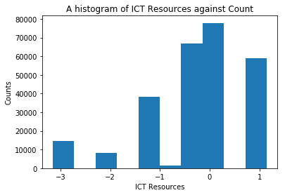

### VIsualization 5: A Scatterplot of ICT Resources against Math Plausible Value Mean

The graph indicates a positive correlation between the two variables. The regression line lies between *400 and 550*.

This indicated that with increase in ICT Resources there will increase in the Math Plausible Value which represents both the Read Plausible Value and Science Plausible Value

```
"'This Function plots a scatter plot'"
```

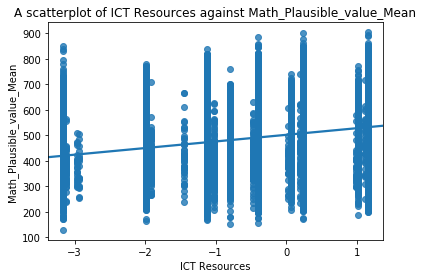

### Visualization 6: A Scatterplot of Wealth against Math_Plausible Value Mean

The graph also indicates a positive correlation between the two variables with the regression line lying between *400 and 600*

This means as wealth increases the Math Plausible Value Mean also increases.

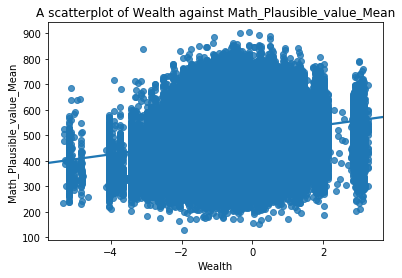

[output not shown]

### Visualization 8: A Colored Scatterplot between the Plausible Value Means and Wealth

```
* Have a low Plasible Value Mean of both Math and Read
* Have an average Plausible Value Mean of both math and Read
```

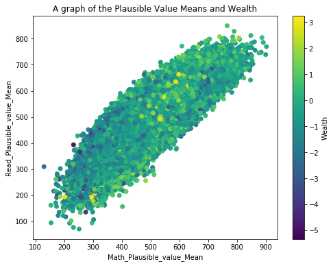